# R Notebook

## 1.1 File metadata

Script written by Katie Wang, modified from code by Morgan Carr-Markell. Created on April 4, 2023.

## 1.2 Data sources

- Species occurrence data:

GBIF.org (03 April 2023) GBIF Occurrence Download https://doi.org/10.15468/dl.nepwjz

- Environmental data:

Tyberghein L, Verbruggen H, Pauly K, Troupin C, Mineur F, De Clerck O (2012) Bio-ORACLE: A global environmental dataset for marine species distribution modelling. Global Ecology and Biogeography, 21, 272–281.

Assis, J., Tyberghein, L., Bosh, S., Verbruggen, H., Serrão, E. A., & De Clerck, O. (2017). Bio-ORACLE v2.0: Extending marine data layers for bioclimatic modelling. Global Ecology and Biogeography.

## 1.3 Code sources

Code is inspired by or modified from the following sources:

The Banta Lab - Tutorials. (n.d.). Sites.google.com. Retrieved April 15, 2023, from https://sites.google.com/site/thebantalab/tutorials?authuser=0

Gee, A., Adolph, S., Furman, D., & Halvorsen, S. (2019). (Re)Searching for an Answer | Summer 2019. Harvey Mudd College Magazine. https://magazine.hmc.edu/summer-2019/researching-for-an-answer/

Kass, J. M., Muscarella, R., Pinilla-Buitrago, G. E., & Galante, P. J. (2023, January 9). ENMeval 2.0 Vignette. Jamiemkass.github.io. https://jamiemkass.github.io/ENMeval/articles/ENMeval-2.0-vignette.html

Watt, D. (2018, October 9). Preparing Data for MaxEnt Species Distribution Modeling Using R. Azavea. https://www.azavea.com/blog/2018/10/09/preparing-data-for-maxent-species-distribution-modeling-using-r/

## 1.4 Libraries

```r
library(tidyverse)    # wrangle data
library(sf)           # vector data
library(dismo)        # species distribution modeling
library(rgdal)        # projections and geospatial functions
library(raster)       # raster data
library(rJava)        # R to Java interface
library(maptools)     # helps with manipulating geographic data
library(sp)           # classes for manipulating spatial data
library(rgeos)        # interface to geometry engine
library(randomForest) # classification and regression random forest models
library(ipred)        # improved prediction using techniques such as bagging
```

## 1.5 Read in data

The inputs for this script were generated by data_processing.Rmd, and can be found in the processed_data folder.

### 1.5.1 Responses (points):

Read in the point data (csv files) for occurrence (aka presence) points and background points. Occurrence points represent where the species was actually found, so it logically follows that the environmental locations where they are found make for a suitable habitat. Background points are randomly sampled from the area around the occurrence points, and on average they do not coincide with occurrence points.  
The species of interest is Callinectes sapidus, an Atlantic crab that is invasive in European waters.

```r
occurrence <- read.csv("processed_data/CS_occurrences.csv")

background <- read.csv("processed_data/background.csv")
```

### 1.5.2 Environmental predictor variables (rasters):

The environmental predictor layers processed in data_processing.Rmd are read in, and a raster stack is made from them. Note that when these files were exported from data_processing.Rmd, the .tif file extension replaced whatever came after the last period in the file name. That is why these file names differ slightly from what is found in the data folder.  
Two raster stacks are made: one for present climate predictors and one for future climate predictors. The future climate predictors are projected for 2040-2050.

```r
# Get raster file list
predictor_list_present <- c("processed_data/Present.Benthic.Max.Depth.Temperature.Lt.tif",
                    "processed_data/Present.Benthic.Max.Depth.Salinity.Lt.tif")
predictor_list_future <- c("processed_data/X2050AOGCM.RCP85.Benthic.Max.Depth.Temperature.Lt.min.tif.tif",
                           "processed_data/X2050AOGCM.RCP85.Benthic.Max.Depth.Salinity.Lt.min.tif.tif")

# Make raster stack from files
predictors_present <- stack(predictor_list_present)
predictors_future <- stack(predictor_list_future)

# Show details about the raster stacks
predictors_present
```

```
class      : RasterStack
dimensions : 1260, 1733, 2183580, 2  (nrow, ncol, ncell, nlayers)
resolution : 0.08333333, 0.08333333  (x, y)
extent     : -103.6667, 40.75, -41.33333, 63.66667  (xmin, xmax, ymin, ymax)
crs        : +proj=longlat +datum=WGS84 +no_defs
names      :   layer.1,   layer.2
min values : -1.890870,  4.969467
max values :  28.55638,  40.56975
```

```r
predictors_future
```

```
class      : RasterStack
dimensions : 1260, 1733, 2183580, 2  (nrow, ncol, ncell, nlayers)
resolution : 0.08333333, 0.08333333  (x, y)
extent     : -103.6667, 40.75, -41.33333, 63.66667  (xmin, xmax, ymin, ymax)
crs        : +proj=longlat +datum=WGS84 +no_defs
names      :   layer.1,   layer.2
min values : -1.940000,  4.972535
max values :  29.70599,  40.56604
```

## 1.6 Processing data

### 1.6.1 Renaming layers in stack

As shown above, the default names for layers in a raster stack are in the format of “layer.X” where X is the layer number. Layers were renamed to represent the predictor variables they represent, going in the same order as in predictor_list_present and predictor_list_future. The names of the variables in the two raster stacks should be the same and in the same order for the sake of consistency, though it may be the case that only the order of raster layers matters.

```r
names(predictors_present) <- c("Temperature", "Salinity")
names(predictors_future) <- c("Temperature", "Salinity")

# check that the raster layers have been renamed
predictors_present
```

```
class      : RasterStack
dimensions : 1260, 1733, 2183580, 2  (nrow, ncol, ncell, nlayers)
resolution : 0.08333333, 0.08333333  (x, y)
extent     : -103.6667, 40.75, -41.33333, 63.66667  (xmin, xmax, ymin, ymax)
crs        : +proj=longlat +datum=WGS84 +no_defs
names      : Temperature,  Salinity
min values :   -1.890870,  4.969467
max values :    28.55638,  40.56975
```

```r
predictors_future
```

```
class      : RasterStack
dimensions : 1260, 1733, 2183580, 2  (nrow, ncol, ncell, nlayers)
resolution : 0.08333333, 0.08333333  (x, y)
extent     : -103.6667, 40.75, -41.33333, 63.66667  (xmin, xmax, ymin, ymax)
crs        : +proj=longlat +datum=WGS84 +no_defs
names      : Temperature,  Salinity
min values :   -1.940000,  4.972535
max values :    29.70599,  40.56604
```

If any of the raster layers are categorical, they must be converted to factors so they are not treated as numbers. This does not apply here, so code for that conversion is omitted.

### 1.6.2 Dividing the points into training and testing sets

The presence points are allocated into a training set (presence_train) to train the model as well as a held-out test set (presence_test). The test set will be used later to assess how well the model predicts areas with high and low suitability for this species. About 80% of the presence points go into the training set, while the remaining 20% go into the test set.

```r
set.seed(100) # decided this seed using random number generator

group <- sample(x = c(1, 2, 3, 4, 5), # we want to assign group numbers
                size = nrow(occurrence), # to each row (observation)
                replace = T) # this means it will keep randomly drawing 1-5

presence_train <- occurrence[group != 1, ] # make a training set of ~80 percent
presence_test <- occurrence[group == 1, ] # make a testing set of ~20 percent
```

The same allocation process is done for the background points.

```r
set.seed(100) # decided this seed using random number generator

group <- sample(x = c(1, 2, 3, 4, 5),
                size = nrow(background),
                replace = T)

background_train <- background[group != 1, ] #make a train set of ~80 percent
background_test <- background[group == 1, ] #make a test set of ~20 percent
```

raster::extract was used to determine what values of the predictor variables (temperature and salinity) are, in the present, associated with the coordinates of each of the presence points (presence_test) and background points (background_test).  
Following that, the environ_train dataframe was made by combining training points for presence and background, then adding the presence_background column which has a 1 corresponding to all presence points and 0 corresponding to all background points.

```r
set.seed(100) # decided this seed using random number generator

# separately for the presence points and background points, extract predictor_present raster values
presence_test <- raster::extract(predictors_present, presence_test) %>%
  data.frame()

background_test <- raster::extract(predictors_present, background_test) %>%
  data.frame()

# create environ_train
# combine training points
train <- rbind(presence_train, background_train)

# col of ones and zeros representing presence or background
pb_train <- c(rep(1, nrow(presence_train)), rep(0, nrow(background_train)))

# extract raster values for training background and presence
environ_train <- raster::extract(predictors_present, train)

# add presence/background column
environ_train <- cbind(presence_background = pb_train, environ_train) %>%
  data.frame() # make into a data frame

# remove any NAs
presence_test <- presence_test[complete.cases(presence_test),]

background_test <- background_test[complete.cases(background_test),]

environ_train <- environ_train[complete.cases(environ_train),]
```

## 1.7 Fitting a Random Forest model

A Random Forest model is one of many kinds of machine learning algorithms used for ecological predictions, such as whether a species will be present or absent at a location given a certain combination of environmental variables (which is the focus of this study. It generates decision trees for which the input is a set of conditions and the output is a yes or no.  
In this model, temperature and salinity are the variables that predict whether C. sapidus is present or absent at any given location. (Background points serve as a proxy for species absence, but without having to make the assumption that the species was truly absent from the location. There is a difference between determining that a species is absent and simply not searching hard enough to find the species.)  
Ignore the warning that says “The response has five or fewer unique values. Are you sure you want to do regression?”

```r
rf_model <- randomForest(presence_background ~  Temperature + Salinity,
                         # model specifies response variable and predictor variables
                         data = environ_train, # the data frame of training data
                         coob = TRUE) # calculates the "out of bag" error
```

```
Warning: The response has five or fewer unique values.  Are you sure you want to do regression?
```

```r
# view the model
rf_model
```

```
Call:
 randomForest(formula = presence_background ~ Temperature + Salinity,      data = environ_train, coob = TRUE)
               Type of random forest: regression
                     Number of trees: 500
No. of variables tried at each split: 1

          Mean of squared residuals: 0.05160231
                    % Var explained: 56.65
```

### 1.7.1 Assessing model performance with the test data

The predictors from the held-out test data are fed into rf_model in order to make dataframes of model predictions (predict_test_presence for presence, predict_test_background for background).

```r
# These two lines fix an error in which R decided that the df was not in
# the right format for the predict function
presence_test <- rbind(environ_train[1, -1] , presence_test)
presence_test <- presence_test[-1, ]

# The base R predict function lets us use any model to make predictions from new data
predict_test_presence <- predict(object = rf_model,
                                 newdata = presence_test)

# Do the same thing for background_test
background_test <- rbind(environ_train[1, -1] , background_test)
background_test <- background_test[-1, ]


predict_test_background <- predict(object = rf_model,
                                 newdata = background_test)
```

Box plots are made to compare the predictions for presence test points and background test points. The predictions from the presence and background test points (predict_test_presence and predict_test_background respectively) are combined into a single dataframe, rf_predictions_present, so they can be plotted as a box plot. Before they are combined, a presence_background column is added (once again using 1 for presence and 0 for background) so that the presence and background predictions can be plotted as separate box plots. When plotting, use factor(presence_background) rather than just presence_background for the x aesthetic, or R will treat it as a number.

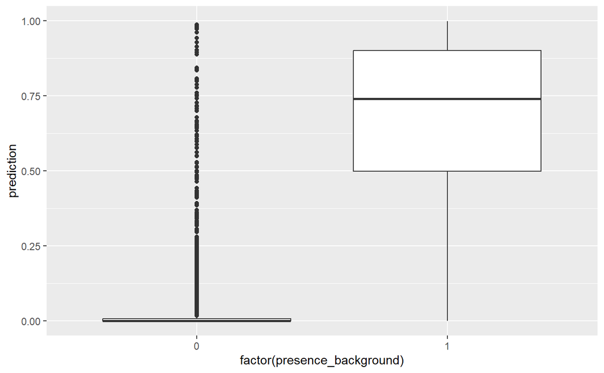

```r
# Mutating in a presence_background column
# Also note that predict_test_presence and predict_test_background are both renamed
# to prediction so that they can be combined in the combined dataframe
predict_test_presence <- data.frame(prediction = predict_test_presence) %>%
  mutate(presence_background = 1)

predict_test_background <- data.frame(prediction = predict_test_background) %>%
  mutate(presence_background = 0)

# Combining the predictions
rf_predictions_present <- rbind(predict_test_presence, predict_test_background)

# making the box plot
rf_predictions_present %>%
  ggplot() +
  geom_boxplot(aes(x = factor(presence_background), y = prediction))
```

### 1.7.2 Plotting the predictions across the landscape with present data and with future climate projections

The raster::predict() function is used to map the predicted probability of encountering C. sapidus at any marine location given the values of its predictor variables. This probability is depicted in a gradient from white to red to green, corresponding to values from 0.0 to 1.0 (0% to 100%).  
There are three arguments used here: the raster stack of predictors, the model to use for predictions, and the extent of the map to generate. * To generate a map for the present climate conditions, use predictors_present as the raster stack. Likewise for the projected future climate conditions and predictors_future. * rf_model, the model that was trained on the present climate conditions with present occurrence points, is used to predict likelihoods for both the present and future climate conditions. * The extents are cropped to the Mediterranean Sea (including the Black Sea) because the spread of invasive C. sapidus in European waters is a topic of concern.

```r
predictions_rf_model_present <- raster::predict(predictors_present,
                                                rf_model,
                                                ext = c(-10, 50, 30, 50))

# for the future, you still use the model you trained on the present data
predictions_rf_model_future <- raster::predict(predictors_future,
                                                rf_model,
                                                ext = c(-10, 50, 30, 50))
```

The layer with the predictions was plotted, with occurrence and background points also plotted on top to assess whether the predictions seem reasonable. Indeed, the black points (which are the occurrence points) coincide with green areas (which are areas predicted to have high probability) so that suggests that the model works well enough.

```r
if (!dir.exists("figures")){
  dir.create("figures")
}

# Set the location to save the plot
png(filename = 'figures/predictions_present.png',pointsize=5, width=2800, height=2000, res=800)
# Then make the plot
plot(predictions_rf_model_present, main = 'Random Forest predicted probabilities')
points(background, col = 'red', pch = 16, cex = 0.2)
points(occurrence, col = 'black', pch = 16, cex = 0.2)
```

A copy of this figure without points plotted on top was also made for easier viewing of the probabilities.

```r
png(filename = 'figures/predictions_present_no_points.png',pointsize=5, width=2800, height=2000, res=800)
plot(predictions_rf_model_present, main = 'Random Forest predicted probabilities')
```

For a presentation, made a copy of this figure with only the occurrence points. Didn’t save it to an image file though.

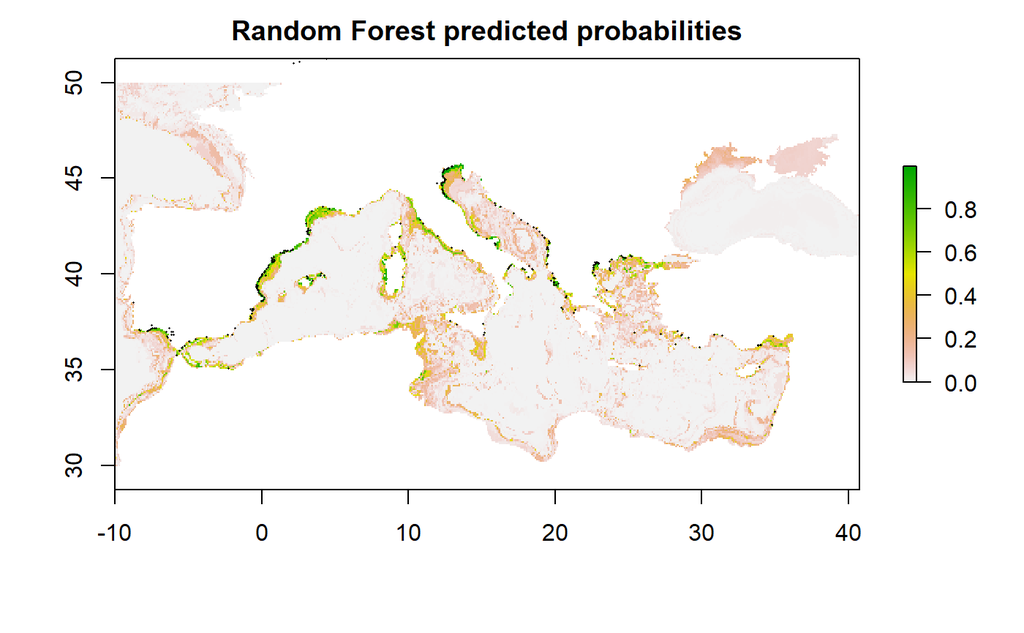

```r
plot(predictions_rf_model_present, main = 'Random Forest predicted probabilities')
points(occurrence, col = 'black', pch = 16, cex = 0.2)
```

Also generated and saved a plot for the future probability predictions. This does not have any points plotted on top because all the occurrence points are from the present and therefore do not correlate with the future climate.

```r
png(filename = 'figures/predictions_future.png',pointsize=5, width=2800, height=2000, res=800)
# Then make the plot
plot(predictions_rf_model_future, main = 'Random Forest predicted probabilities')
```

## 1.8 Calculating area of regions above a suitability threshold

Now we compare the amount of area marked as sufficiently suitable for C. sapidus (i.e. above a certain threshold) between the present and future climate conditions in order to determine whether C. sapidus will expand its range or not.  
To determine the threshold to use, run the evaluate() function on the held-out test data (presence_test and background_test) and the model (rf_model) and pick the “max TPR+TNR at” value as the threshold. This is the value at which the model’s predictions align the most closely with the ground truth of the test data, since the true positive rate and true negative rate are maximized there. Use the same threshold for area calculations for both models.

```r
evaluate(presence_test, background_test, rf_model)
```

[output not shown]

```r
# assign threshold value to a variable so it can be changed easiler
threshold = 0.1369337
```

I will plot the box plot again, but with the suitability threshold plotted on top. If the threshold has been chosen well, the presence points should lie mostly above the threshold, and the background points should lie mostly below.

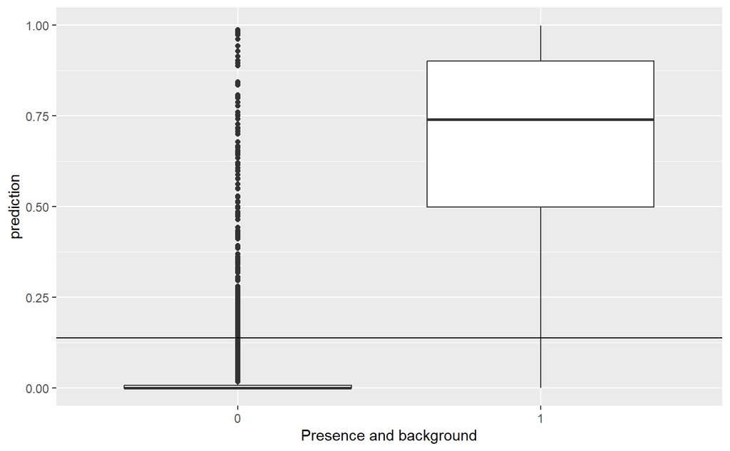

```r
# making the box plot
rf_predictions_present %>%
  ggplot() +
  geom_boxplot(aes(x = factor(presence_background), y = prediction)) +
  geom_hline(yintercept = threshold) + # plot the threshold
  xlab("Presence and background") # in the figure caption, specify that 1=presence
# and 0=background

# saving the box plot
ggsave("figures/box_plot_with_threshold.png")
```

The threshold looks appropriate. Also, to get a sense of what proportion of points lie in each quadrant (true positive, false positive, true negative, false negative), a table is generated. Both group_by conditions have to be in the same group_by() call; if two group_by() calls are made, the table will only be split into rows by the latter group_by() call.

```r
confusion_matrix_df <- rf_predictions_present %>%
  group_by(presence_background,
           prediction >= threshold) %>%
  summarize(n=n())
# taking steps to convert this table into a confusion matrix
confusion_matrix_df$prediction_gt_threshold <- c("True negative",
                                                 "False positive",
                                                 "False negative",
                                                 "True positive")

confusion_matrix_df <- confusion_matrix_df %>%
  ungroup() %>% #otherwise the table will keep the presence_background column
  dplyr::select(prediction_gt_threshold, n)

confusion_matrix_df_wide <- pivot_wider(data = confusion_matrix_df,
names_from = prediction_gt_threshold,
# names_from gives the column to take values to make into separate columns
values_from = n) # values to put into those separate columns

confusion_matrix_df_wide
```

| True negative | False positive | False negative | True positive |
| --- | --- | --- | --- |
| 1800 | 199 | 22 | 302 |

0 is for background while 1 is for presence. We can consider presence points above the threshold as true positives, since they are actual occurrences and the model predicted them to be actual occurrences (i.e. the probability assigned by the model did exceed the threshold) and background points below the threshold as true negatives, since these weren’t actual occurrence points (though some of them might be in close proximity to actual occurrence points) and were correctly predicted to not be occurrence points.

Proceeding to area calculations.

```r
# Area calculation for present range

# save and then modify full raster
predictions_present <- predictions_rf_model_present
predictions_present[predictions_present <= threshold] <- NA

# get sizes of all cells with suitability over threshold
cell_size <- area(predictions_present,
                  na.rm = TRUE,
                  weights = FALSE)

# delete any NAs from vector of all raster cells
cell_size <- cell_size[!is.na(cell_size)]

# compute area [km2] of all cells in prediction_over50
suitable_area_present <- length(cell_size)*mean(cell_size)

suitable_area_present
```

```
[1] 451025.3
```

```r
# Area calculation for future range

# save and then modify full raster
predictions_future <- predictions_rf_model_future
predictions_future[predictions_future <= threshold] <- NA

# get sizes of all cells with suitability over threshold
cell_size <- area(predictions_future,
                  na.rm = TRUE,
                  weights = FALSE)

# delete any NAs from vector of all raster cells
cell_size <- cell_size[!is.na(cell_size)]

# compute area [km2] of all cells in prediction_over50
suitable_area_future <- length(cell_size)*mean(cell_size)

suitable_area_future
```

```
[1] 519619.1
```